# Primer Trabajo Grupal

Omar David Mercado -omercado@unal.edu.co Zuleima Carriazo- zcarriazo@unal.edu.co ESteban Grajales-jgrajalesh@unal.edu.co Juan José Hurtado- jjhurtadoa@unal.edu.co Juan Manuel Sierra- jmsierraa@unal.edu.co

Miercoles 14 de Abril de 2021

##### Valiendonos de las múltiples opciones que tenemos para presentar este proyecto, hacemos uso de estas bibliotecas en particular

###### Se realiza la lectura de la base de datos de la que vamos a tomar información para realizar un analisis gráfico/exploratorio de lo que podamos encontrar en ella; se codifica con *UTF-08* para una lectura adecuada que permita tildes y letras en español.

##### Se muestran en el archivo los primeros 6 registros de la base de datos en cuestión, para dar una idea lo que pueda contener ésta misma.

```
##   Respuesta         Enviado.el.    Q01_Genero Q02_FechaNac
## 1      2439 26/02/2021 09:43:10 1 : Masculino   1997-01-17
## 2      2459 26/02/2021 09:47:45 1 : Masculino   1998-07-26
## 3      2517 26/02/2021 09:56:39 1 : Masculino   1996-09-05
## 4      2448 26/02/2021 09:55:11 1 : Masculino   1997-01-20
## 5      2499 26/02/2021 09:56:13 1 : Masculino   1990-08-23
## 6      2505 26/02/2021 09:46:19 1 : Masculino   1982-07-19
##                                Q03_Carrera Q04_Semestre Q05_Saber11
## 1                          1 : Matemáticas          7.0         420
## 2 2 : Ingeniería de sistemas e informática          5.3         347
## 3 2 : Ingeniería de sistemas e informática          7.7         270
## 4 2 : Ingeniería de sistemas e informática          6.0         325
## 5 2 : Ingeniería de sistemas e informática          7.6         430
## 6 2 : Ingeniería de sistemas e informática          4.0           0
##   Q06_PercentilSaber11 Q07_FechaSaber11 Q08_PAPA Q09_EnAreaMetropolitana
```

[output cut: 146 more lines]

###### Se hace una revisión de las variables contenidas en la base de datos para mirar a que tipo pertenecen, y posteriormente convertirlas a otro para trabajarlas a nuestra conveniencia

```
## Rows: 87
## Columns: 44
## $ Respuesta                                                                   <int> ~
## $ Enviado.el.                                                                 <chr> ~
## $ Q01_Genero                                                                  <chr> ~
## $ Q02_FechaNac                                                                <chr> ~
## $ Q03_Carrera                                                                 <chr> ~
## $ Q04_Semestre                                                                <dbl> ~
## $ Q05_Saber11                                                                 <int> ~
## $ Q06_PercentilSaber11                                                        <dbl> ~
## $ Q07_FechaSaber11                                                            <chr> ~
## $ Q08_PAPA                                                                    <dbl> ~
## $ Q09_EnAreaMetropolitana                                                     <int> ~
## $ Q10_Estrato                                                                 <chr> ~
## $ Q11_R                                                                       <int> ~
```

[output cut: 31 more lines]

```
##    Respuesta    Enviado.el.         Q01_Genero        Q02_FechaNac
##  Min.   :2429   Length:87          Length:87          Length:87
##  1st Qu.:2450   Class :character   Class :character   Class :character
##  Median :2472   Mode  :character   Mode  :character   Mode  :character
##  Mean   :2472
##  3rd Qu.:2494
##  Max.   :2517
##
##  Q03_Carrera         Q04_Semestre    Q05_Saber11    Q06_PercentilSaber11
##  Length:87          Min.   :1.500   Min.   :  0.0   Min.   :  0.00
##  Class :character   1st Qu.:2.000   1st Qu.:298.5   1st Qu.: 74.50
##  Mode  :character   Median :3.000   Median :327.0   Median : 88.00
##                     Mean   :3.543   Mean   :322.0   Mean   : 82.78
##                     3rd Qu.:5.000   3rd Qu.:358.5   3rd Qu.: 96.50
##                     Max.   :8.000   Max.   :580.0   Max.   :260.00
##                     NA's   :1
##  Q07_FechaSaber11      Q08_PAPA      Q09_EnAreaMetropolitana Q10_Estrato
##  Length:87          Min.   : 3.000   Min.   :0.0000          Length:87
##  Class :character   1st Qu.: 3.800   1st Qu.:0.0000          Class :character
##  Mode  :character   Median : 4.100   Median :1.0000          Mode  :character
##                     Mean   : 4.562   Mean   :0.7241
##                     3rd Qu.: 4.300   3rd Qu.:1.0000
##                     Max.   :45.000   Max.   :1.0000
##                     NA's   :9
##      Q11_R         Q12_RStudio     Q13_NoRoRStudio
##  Min.   :0.0000   Min.   :0.0000   Length:87
##  1st Qu.:1.0000   1st Qu.:1.0000   Class :character
##  Median :1.0000   Median :1.0000   Mode  :character
##  Mean   :0.9195   Mean   :0.8736
##  3rd Qu.:1.0000   3rd Qu.:1.0000
##  Max.   :1.0000   Max.   :1.0000
##
##  Q14_RecursosInformaticos..Internet.de.cable.propio
##  Min.   :0.0000
##  1st Qu.:0.0000
##  Median :0.0000
##  Mean   :0.4483
##  3rd Qu.:1.0000
##  Max.   :1.0000
##
```

[output cut: 121 more lines]

```
##  Min.   :0.0000                   Min.   :0.0000
##  1st Qu.:1.0000                   1st Qu.:0.0000
##  Median :1.0000                   Median :0.0000
##  Mean   :0.7816                   Mean   :0.3333
##  3rd Qu.:1.0000                   3rd Qu.:1.0000
##  Max.   :1.0000                   Max.   :1.0000
##
##  Q27_PorcentDivisor
##  Min.   :  0.50
##  1st Qu.: 33.50
##  Median : 60.00
##  Mean   : 53.46
##  3rd Qu.: 70.00
##  Max.   :100.00
##  NA's   :1
```

##### Se cambian las variables de tipo caracter a factor sobre una nueva base de datos replicada; para un adecuado manejo de los resultados encontrados en éstas en su análisis descriptivo

##### Como primer depurado; se convierte el asignado de la primera variable **Respuesta** a tipo character, pues se considera que con estas cifras no debemos hacer ningún tipo de cálculo matemático como para dejarla ser *entero*

##### Tambien se convierte a tipo factor las variables en lenguaje binario, representando como *Si* al número *1*, para una mayor claridad al público,en la lectura de la base de datos

```
##    Respuesta               Enviado.el.         Q01_Genero     Q02_FechaNac
##  2429   : 1   26/02/2021 09:42:30: 2   1 : Masculino:66   2002-09-14: 2
##  2430   : 1   26/02/2021 09:43:02: 2   2 : Femenino :20   2002-11-23: 2
##  2431   : 1   26/02/2021 09:43:10: 2   3 : Otro     : 1   1982-07-19: 1
##  2432   : 1   26/02/2021 09:46:02: 2                      1988-02-19: 1
##  2433   : 1   26/02/2021 09:46:19: 2                      1990-08-23: 1
##  2434   : 1   26/02/2021 09:47:08: 2                      1993-02-26: 1
##  (Other):81   (Other)            :75                      (Other)   :79
##                                    Q03_Carrera  Q04_Semestre    Q05_Saber11
##  1 : Matemáticas                         : 2   Min.   :1.500   Min.   :  0.0
##  2 : Ingeniería de sistemas e informática:26   1st Qu.:2.000   1st Qu.:298.5
##  3 : Estadística                         :54   Median :3.000   Median :327.0
##  4 : Ingeniería administrativa           : 1   Mean   :3.543   Mean   :322.0
##  5 : Ingeniería física                   : 1   3rd Qu.:5.000   3rd Qu.:358.5
##  6 : Ingeniería industrial               : 2   Max.   :8.000   Max.   :580.0
##  7 : Otra                                : 1   NA's   :1
##  Q06_PercentilSaber11   Q07_FechaSaber11    Q08_PAPA
##  Min.   :  0.00       2019-08-11:13      Min.   : 3.000
##  1st Qu.: 74.50       2016-07-31: 7      1st Qu.: 3.800
##  Median : 88.00       2017-08-27: 7      Median : 4.100
##  Mean   : 82.78       2018-08-12: 7      Mean   : 4.562
##  3rd Qu.: 96.50       2015-08-02: 3      3rd Qu.: 4.300
##  Max.   :260.00       2013-08-25: 2      Max.   :45.000
##                       (Other)   :48      NA's   :9
##  Q09_EnAreaMetropolitana           Q10_Estrato Q11_R   Q12_RStudio
##  No:24                   2 : 1           : 8   No: 7   No:11
##  Si:63                   3 : 2           :26   Si:80   Si:76
##                          4 : 3           :45
##                          5 : 4           : 6
##                          6 : 5           : 1
##                          8 : No se conoce: 1
##
##                                                                                           Q13_NoRoRStudio
##                                                                                                   :76
##  0                                                                                                : 1
##  Al momento de ingresar me salta en error del software                                            : 1
##  lo tengo instalado pero los paquetes no me los deja instalar.                                    : 1
##  n/a                                                                                              : 1
##  No cuento con capacidad para descargar estos programas, estoy a la espera de un nuevo computador : 1
##  (Other)                                                                                          : 6
```

[output cut: 129 more lines]

```
##  No:29                             No:19
##  Si:58                             Si:68
##
##
##
##
##
##  Q26_Divisor..f.es.divisor.de.h.g Q27_PorcentDivisor
##  No:58                            Min.   :  0.50
##  Si:29                            1st Qu.: 33.50
##                                   Median : 60.00
##                                   Mean   : 53.46
##                                   3rd Qu.: 70.00
##                                   Max.   :100.00
##                                   NA's   :1
```

```
## Rows: 87
## Columns: 44
## $ Respuesta                                                                   <fct> ~
## $ Enviado.el.                                                                 <fct> ~
## $ Q01_Genero                                                                  <fct> ~
## $ Q02_FechaNac                                                                <fct> ~
## $ Q03_Carrera                                                                 <fct> ~
## $ Q04_Semestre                                                                <dbl> ~
## $ Q05_Saber11                                                                 <int> ~
## $ Q06_PercentilSaber11                                                        <dbl> ~
## $ Q07_FechaSaber11                                                            <fct> ~
## $ Q08_PAPA                                                                    <dbl> ~
## $ Q09_EnAreaMetropolitana                                                     <fct> ~
## $ Q10_Estrato                                                                 <fct> ~
## $ Q11_R                                                                       <fct> ~
```

[output cut: 31 more lines]

# ANÁLISIS UNIVARIADO

##### Análisis de la variable género

```
##
## 1 : Masculino  2 : Femenino      3 : Otro
##            66            20             1
```

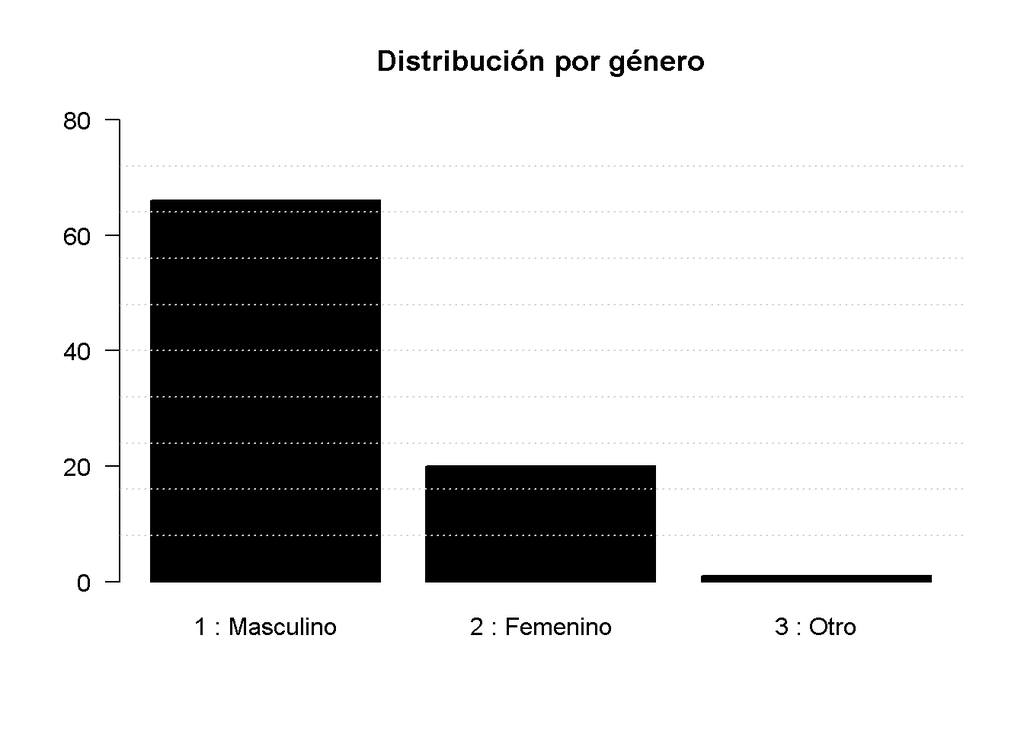

## Análisis de la variable Fecha de nacimiento

```
##         Min.      1st Qu.       Median         Mean      3rd Qu.         Max.
## "1982-07-19" "1998-08-06" "2000-04-19" "1999-08-08" "2001-10-04" "2003-08-16"
```

### Como la variable Fecha de Nacimiento no da claridad de los datos para un análisis, realizamos la conversión de la Fecha de nacimiento a Edad

```
##
## 17.8726899383984 18.3353867214237 18.4093086926762 18.4613278576318
##                1                1                1                1
## 18.4722792607803 18.5051334702259  18.570841889117 18.6009582477755
##                1                1                1                2
## 18.6803559206023  18.757015742642 18.7926078028747  18.798083504449
##                1                1                2                1
## 18.8993839835729 18.9705681040383 18.9924709103354 19.1156741957563
##                1                1                1                1
## 19.3127994524298 19.4332648870637  19.564681724846 19.7262149212868
##                1                1                1                1
## 19.7453798767967 19.7754962354552 19.8384668035592 19.9288158795346
##                1                1                1                1
## 19.9315537303217 19.9507186858316 19.9835728952772 20.0273785078713
##                1                1                1                1
##  20.104038329911 20.1916495550992 20.3340177960301   20.37234770705
##                1                1                1                1
## 20.5366187542779 20.5420944558522 20.6297056810404 20.6707734428474
##                1                1                1                1
## 20.8624229979466 20.8651608487337 21.0020533880903 21.0321697467488
##                1                1                1                1
## 21.1060917180014 21.1964407939767 21.1991786447639 21.2073921971253
##                1                1                1                1
## 21.4948665297741  21.555099247091 21.5633127994524 21.5989048596851
##                1                1                1                1
##  21.864476386037 21.8699520876112 22.1464750171116 22.1820670773443
##                1                1                1                1
## 22.2094455852156 22.4093086926762 22.4284736481862  22.444900752909
##                1                1                1                1
## 22.4585900068446 22.4777549623546 22.4969199178645 22.5954825462012
##                1                1                1                1
## 22.8199863107461  22.839151266256 22.8665297741273 22.9295003422313
##                1                1                1                1
## 22.9678302532512 23.1813826146475 23.2717316906229 23.4086242299795
##                1                1                1                1
## 23.8877481177276 24.4407939767283 24.4490075290897 24.4709103353867
##                1                1                1                1
## 24.8158795345654 24.8925393566051 24.9637234770705 25.0924024640657
##                1                1                1                1
## 25.2183436002738 26.5133470225873  26.715947980835 27.2635181382615
##                1                1                1                1
## 27.6194387405886 28.3394934976044 30.8528405201916 33.3607118412047
##                1                1                1                1
## 38.9486652977413
##                1
```

```
##  [1] 24 22 24 24 30 38 23 26 28 24 27 25 24 21 21 21 21 22 22 21 21 22 20 20 20
## [26] 21 22 19 22 20 21 23 33 19 19 18 20 18 20 19 19 26 22 27 22 19 19 22 19 21
## [51] 19 21 20 20 24 17 18 18 18 23 22 18 18 20 21 18 21 22 20 19 20 18 18 18 19
## [76] 25 18 19 23 18 22 18 22 18 18 22 22
```

```
##    Min. 1st Qu.  Median    Mean 3rd Qu.    Max.
##   17.00   19.00   21.00   21.33   22.00   38.00
```

## Análisis de la variable Carrera

#### Una tabla sencilla que muestra la distribución general de resultados de la variable Carrera de la base de datos; dado que existe un nombre único para cada carrera, no se considera que deba ser depurada, se procederá a ver en grafico la cantidad de estudiantes por carrrera.

```
##
##                          1 : Matemáticas
##                                        2
## 2 : Ingeniería de sistemas e informática
##                                       26
##                          3 : Estadística
##                                       54
##            4 : Ingeniería administrativa
##                                        1
##                    5 : Ingeniería física
##                                        1
##                6 : Ingeniería industrial
##                                        2
##                                 7 : Otra
##                                        1
```

### Se cambian los valores a frecuencia relativa para posteriormente ser graficados.

```
##
##                          1 : Matemáticas
##                                 2.298851
## 2 : Ingeniería de sistemas e informática
##                                29.885057
##                          3 : Estadística
##                                62.068966
##            4 : Ingeniería administrativa
##                                 1.149425
##                    5 : Ingeniería física
##                                 1.149425
##                6 : Ingeniería industrial
##                                 2.298851
##                                 7 : Otra
##                                 1.149425
```

#### Se realizará una gráfica de barras para representar los datos de los estudiantes y sus respectivas carreras, basandonos en su tabla de frecuencia

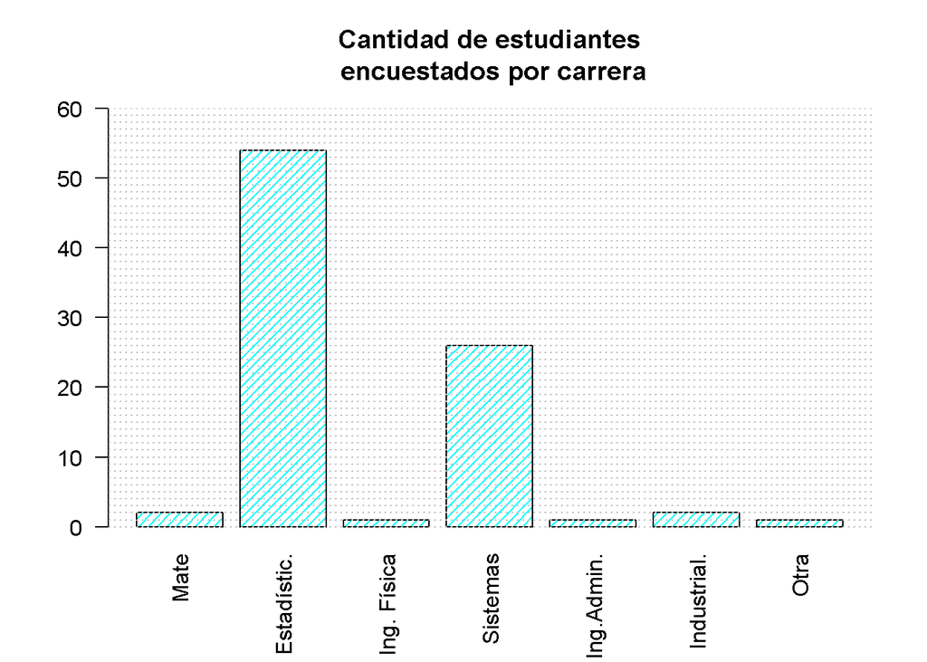

## Análisis de la variable Semestre

```
##    Min. 1st Qu.  Median    Mean 3rd Qu.    Max.    NA's
##   1.500   2.000   3.000   3.543   5.000   8.000       1
```

```
##
## 1.5 1.7   2 2.5   3 3.5   4 4.5 4.6   5 5.2 5.3 5.5 5.6   6   7 7.5 7.6 7.7   8
##   4   1  33   4   5   4  10   1   1   6   1   1   2   1   1   7   1   1   1   1
```

## Análisis de la variable Resultados Pruebas Saber 11

```
##    Min. 1st Qu.  Median    Mean 3rd Qu.    Max.
##     0.0   298.5   327.0   322.0   358.5   580.0
```

```
##   Respuesta         Enviado.el.    Q01_Genero Q02_FechaNac
## 1      2493 26/02/2021 09:48:42 1 : Masculino   1994-03-26
##                                Q03_Carrera Q04_Semestre Q05_Saber11
## 1 2 : Ingeniería de sistemas e informática          7.5         580
##   Q06_PercentilSaber11 Q07_FechaSaber11 Q08_PAPA Q09_EnAreaMetropolitana
## 1                   90       2009-09-16      4.1                      Si
##   Q10_Estrato Q11_R Q12_RStudio Q13_NoRoRStudio
## 1       4 : 3    Si          Si
##   Q14_RecursosInformaticos..Internet.de.cable.propio
## 1                                                 No
##   Q14_RecursosInformaticos..Internet.de.cable.no.propio
## 1                                                    No
##   Q14_RecursosInformaticos..Wifi.propio
## 1                                    Si
##   Q14_RecursosInformaticos..Wifi.no.propio
## 1                                       No
##   Q14_RecursosInformaticos..Celular.sin.datos
## 1                                          Si
##   Q14_RecursosInformaticos..Celular.con.datos
## 1                                          No
##   Q14_RecursosInformaticos..Portátil.propio
## 1                                        Si
##   Q14_RecursosInformaticos..Portátil.no.propio
## 1                                           No
##   Q14_RecursosInformaticos..Computador.de.escritorio.propio.y.exclusivo
## 1                                                                    No
##   Q14_RecursosInformaticos..Computador.de.escritorio.no.propio.pero.exclusivo
## 1                                                                          No
##   Q14_RecursosInformaticos..Computador.propio..pero.no.exclusivo
## 1                                                             No
##   Q14_RecursosInformaticos..Computador.de.escritorio.ni.propio.ni.exclusivo
## 1                                                                        No
##   Q14_RecursosInformaticos..Tablet.sin.datos
## 1                                         No
##   Q14_RecursosInformaticos..Tablet.con.datos. Q15_Alunizaje
## 1                                          No            No
##   Q16_EspionajeInternet Q17_Experimentos Q18_Vacunas Q19_EvidenciaFalsa
## 1                    Si               Si          No                 Si
##   Q20_RafagasSolares Q21_TierraHueca Q22_alienigenas Q23_CambioClimatico
## 1                 No              No              No                  No
##   Q24_area Q25_PorcentArea Q26_Divisor..f.es.divisor.de.g.2.
## 1 4 : 4*pi              60                                Si
##   Q26_Divisor..f.es.divisor.de.gh. Q26_Divisor..f.es.divisor.de.h.g
## 1                               Si                               Si
##   Q27_PorcentDivisor edad
## 1                 65   27
```

##### Se depuran unos resultados que se salen del rango de la respuesta en la variable enc$Q05_Saber11, asumiendo que fue un error de digitación al redactar el valor.

### Distribución de los puntajes de los estudiantes

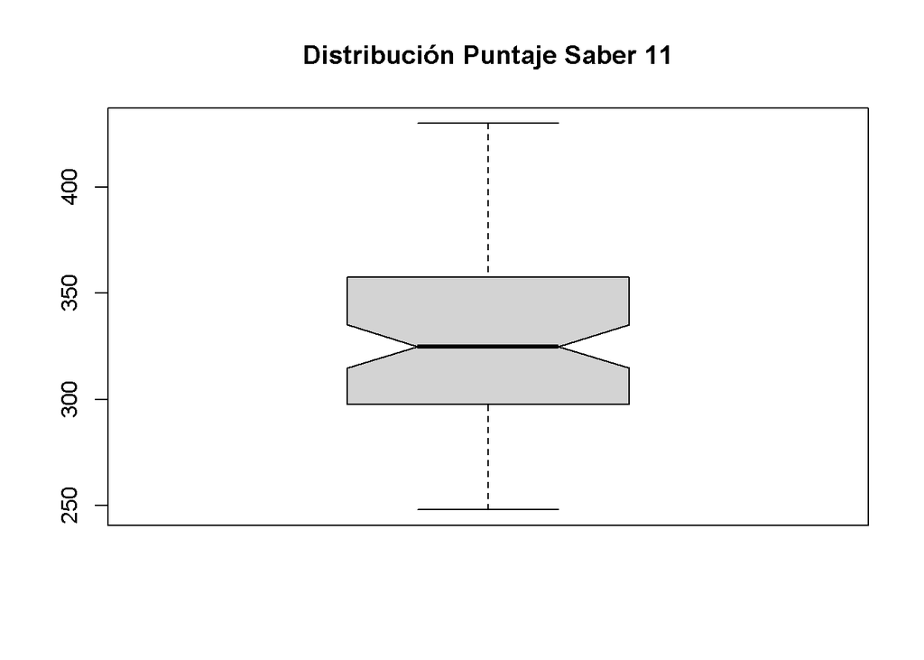

## Análisis de la variable Percentil Pruebas Saber 11

```
##    Min. 1st Qu.  Median    Mean 3rd Qu.    Max.
##    0.00   74.50   88.00   82.78   96.50  260.00
```

```
##   Respuesta         Enviado.el.    Q01_Genero Q02_FechaNac     Q03_Carrera
## 1      2432 26/02/2021 09:38:56 1 : Masculino   1996-07-13 3 : Estadística
## 2      2476 26/02/2021 09:50:29 1 : Masculino   2003-01-09 3 : Estadística
##   Q04_Semestre Q05_Saber11 Q06_PercentilSaber11 Q07_FechaSaber11 Q08_PAPA
## 1            2         286                  230       2015-08-23      4.5
## 2           NA         274                  260       2019-08-11       NA
##   Q09_EnAreaMetropolitana Q10_Estrato Q11_R Q12_RStudio
## 1                      Si       3 : 2    Si          Si
## 2                      No       2 : 1    Si          No
##                                                             Q13_NoRoRStudio
## 1
## 2 RStudio no me permite instalar por que mi sistema operativo es de 32 bits
##   Q14_RecursosInformaticos..Internet.de.cable.propio
## 1                                                 Si
## 2                                                 Si
##   Q14_RecursosInformaticos..Internet.de.cable.no.propio
## 1                                                    No
## 2                                                    No
##   Q14_RecursosInformaticos..Wifi.propio
## 1                                    Si
## 2                                    Si
##   Q14_RecursosInformaticos..Wifi.no.propio
## 1                                       No
## 2                                       No
##   Q14_RecursosInformaticos..Celular.sin.datos
## 1                                          Si
## 2                                          Si
##   Q14_RecursosInformaticos..Celular.con.datos
## 1                                          No
## 2                                          No
##   Q14_RecursosInformaticos..Portátil.propio
## 1                                        Si
## 2                                        No
##   Q14_RecursosInformaticos..Portátil.no.propio
## 1                                           No
## 2                                           Si
##   Q14_RecursosInformaticos..Computador.de.escritorio.propio.y.exclusivo
## 1                                                                    No
## 2                                                                    No
##   Q14_RecursosInformaticos..Computador.de.escritorio.no.propio.pero.exclusivo
```

[output cut: 14 more lines]

```
##   Q16_EspionajeInternet Q17_Experimentos Q18_Vacunas Q19_EvidenciaFalsa
## 1                    No               Si          No                 Si
## 2                    No               No          No                 No
##   Q20_RafagasSolares Q21_TierraHueca Q22_alienigenas Q23_CambioClimatico
## 1                 Si              No              No                  No
## 2                 No              No              Si                  No
##                        Q24_area Q25_PorcentArea
## 1 6 : Ninguna de las anteriores              70
## 2                      5 : 3*pi              70
##   Q26_Divisor..f.es.divisor.de.g.2. Q26_Divisor..f.es.divisor.de.gh.
## 1                                Si                               Si
## 2                                Si                               Si
##   Q26_Divisor..f.es.divisor.de.h.g Q27_PorcentDivisor edad
## 1                               No                 49   24
## 2                               No                 70   18
```

##### Se depuran unos resultados que se salen del rango de la respuesta en la variable enc$Q06_PercentilSaber11

```
##    Min. 1st Qu.  Median    Mean 3rd Qu.    Max.
##    0.00   71.00   88.00   78.42   95.00  100.00
```

### Distribución de los percentiles prueba de los estudiantes

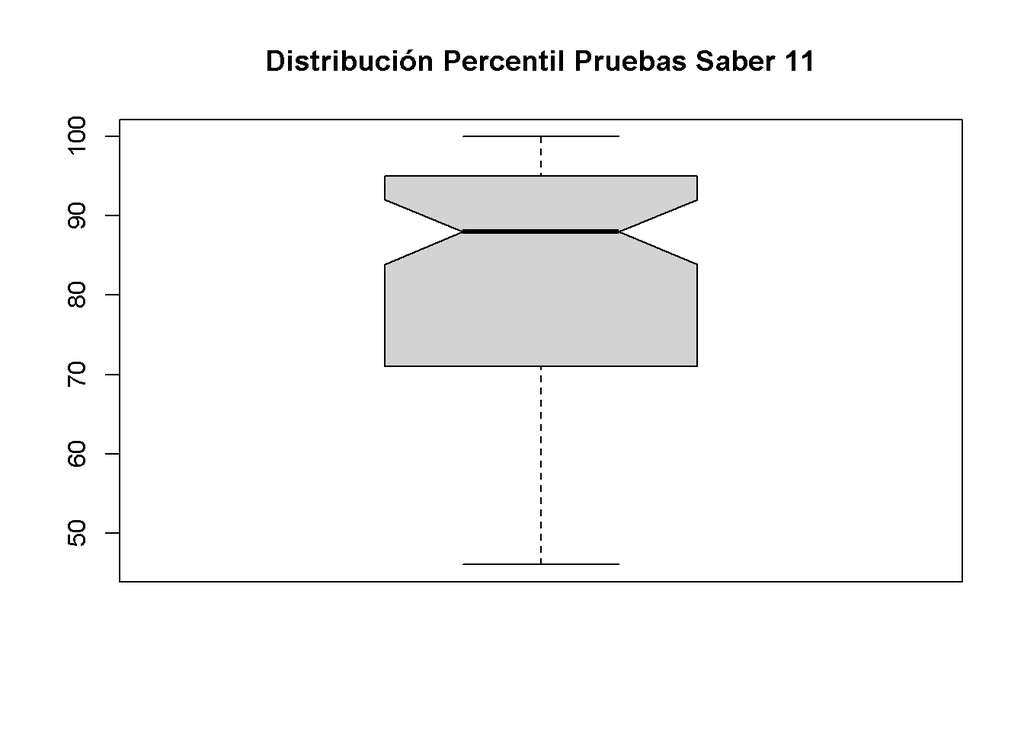

## Análisis de la variable Fecha Pruebas Saber 11

```
##         Min.      1st Qu.       Median         Mean      3rd Qu.         Max.
## "1999-08-21" "2015-08-03" "2017-08-27" "2016-10-05" "2018-10-20" "2021-08-08"
```

### Se toma la decisión de omitir los datos en NA ya que no hacen una gran representacion y se filtra la fila en donde la variable *Q08_PAPA* presenta un error atípico y para tomar la decisión de corregir el dato, pues consideramos que pudo deberse a un error en la digitación de éste

```
##   Respuesta         Enviado.el.    Q01_Genero Q02_FechaNac     Q03_Carrera
## 1      2494 26/02/2021 09:44:43 1 : Masculino   2002-11-23 3 : Estadística
##   Q04_Semestre Q05_Saber11 Q06_PercentilSaber11 Q07_FechaSaber11 Q08_PAPA
## 1            2         262                   63       2019-08-11       45
##   Q09_EnAreaMetropolitana Q10_Estrato Q11_R Q12_RStudio Q13_NoRoRStudio
## 1                      No       3 : 2    Si          Si
##   Q14_RecursosInformaticos..Internet.de.cable.propio
## 1                                                 Si
##   Q14_RecursosInformaticos..Internet.de.cable.no.propio
## 1                                                    No
##   Q14_RecursosInformaticos..Wifi.propio
## 1                                    Si
##   Q14_RecursosInformaticos..Wifi.no.propio
## 1                                       No
##   Q14_RecursosInformaticos..Celular.sin.datos
## 1                                          Si
##   Q14_RecursosInformaticos..Celular.con.datos
## 1                                          No
##   Q14_RecursosInformaticos..Portátil.propio
## 1                                        Si
##   Q14_RecursosInformaticos..Portátil.no.propio
## 1                                           No
##   Q14_RecursosInformaticos..Computador.de.escritorio.propio.y.exclusivo
## 1                                                                    No
##   Q14_RecursosInformaticos..Computador.de.escritorio.no.propio.pero.exclusivo
## 1                                                                          No
##   Q14_RecursosInformaticos..Computador.propio..pero.no.exclusivo
## 1                                                             No
##   Q14_RecursosInformaticos..Computador.de.escritorio.ni.propio.ni.exclusivo
## 1                                                                        No
##   Q14_RecursosInformaticos..Tablet.sin.datos
## 1                                         No
##   Q14_RecursosInformaticos..Tablet.con.datos. Q15_Alunizaje
## 1                                          No            Si
##   Q16_EspionajeInternet Q17_Experimentos Q18_Vacunas Q19_EvidenciaFalsa
## 1                    Si               Si          No                 Si
##   Q20_RafagasSolares Q21_TierraHueca Q22_alienigenas Q23_CambioClimatico
## 1                 No              No              No                  No
##   Q24_area Q25_PorcentArea Q26_Divisor..f.es.divisor.de.g.2.
## 1 4 : 4*pi              70                                Si
##   Q26_Divisor..f.es.divisor.de.gh. Q26_Divisor..f.es.divisor.de.h.g
## 1                               No                               Si
##   Q27_PorcentDivisor edad
## 1                 60   18
```

```
##    Min. 1st Qu.  Median    Mean 3rd Qu.    Max.    NA's
##   3.000   3.800   4.100   4.042   4.300   4.700       9
```

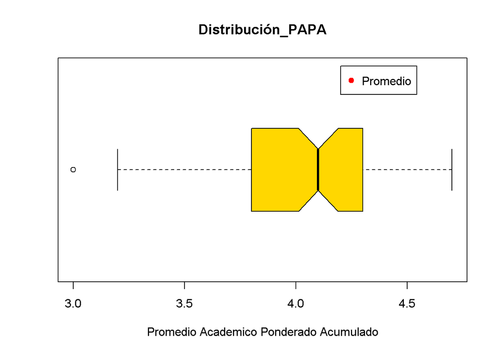

## Análisis de la variable Reside en el Área Metropolitana

```
## No Si
## 24 63
```

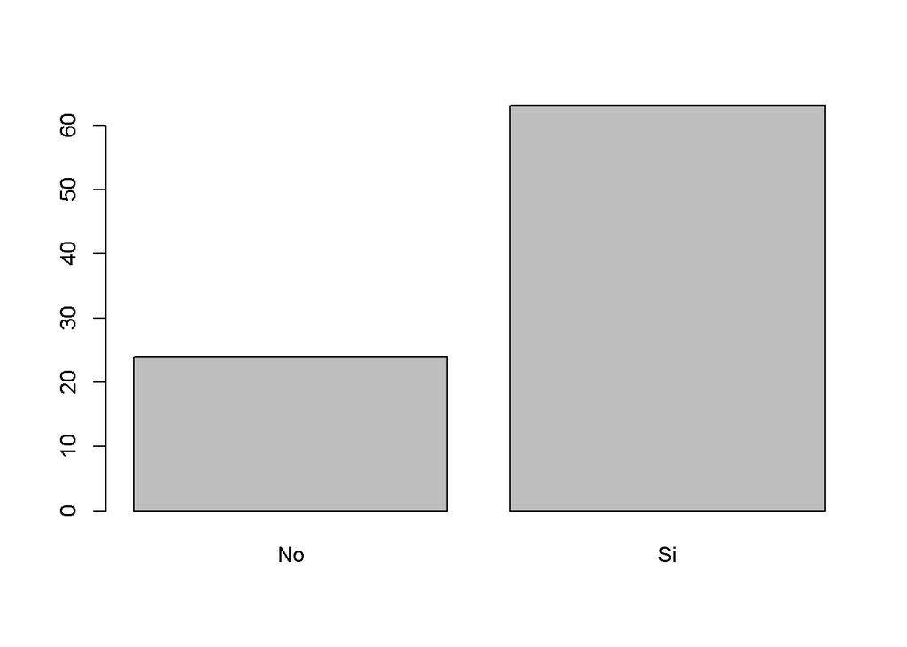

## Análisis de la variable Estrato

```
##            2 : 1            3 : 2            4 : 3            5 : 4
##                8               26               45                6
##            6 : 5 8 : No se conoce
##                1                1
```

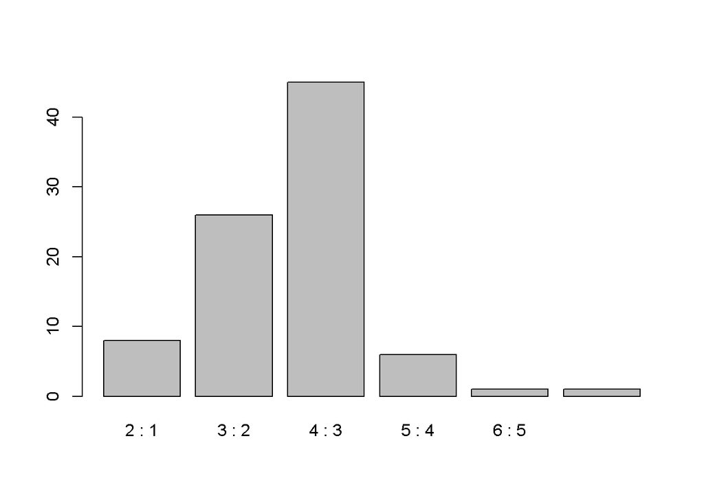

## Análisis de la variable Tiene o no Tiene R

```
## No Si
##  7 80
```

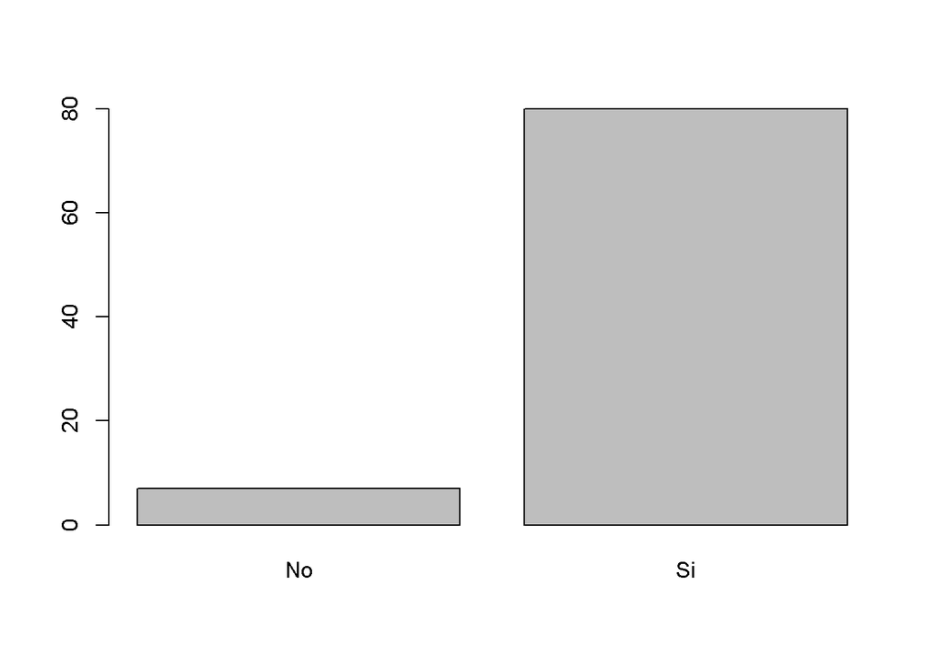

## Análisis de la variable Tiene o no Tiene R Studio

```
## No Si
## 11 76
```

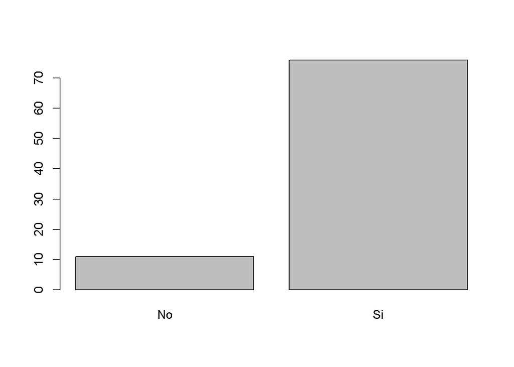

### Se omite la Pregunta 13 ya que esta son justificaciones del encuestado.

## Análisis de la variable Recursos Informaticos

```
## No Si
## 48 39
```

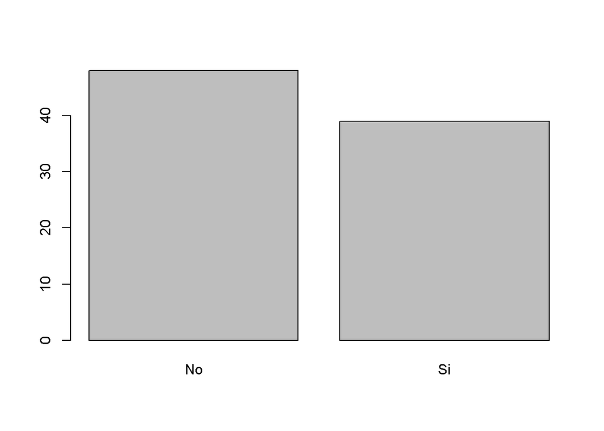

```
## No Si
## 85  2
```

```
## No Si
## 12 75
```

```
## No Si
## 42 45
```

```
## No Si
## 78  9
```

```
## No Si
## 86  1
```

```
## No Si
## 82  5
```

```
## No Si
## 16 71
```

```
## No Si
## 12 75
```

```
## No Si
## 76 11
```

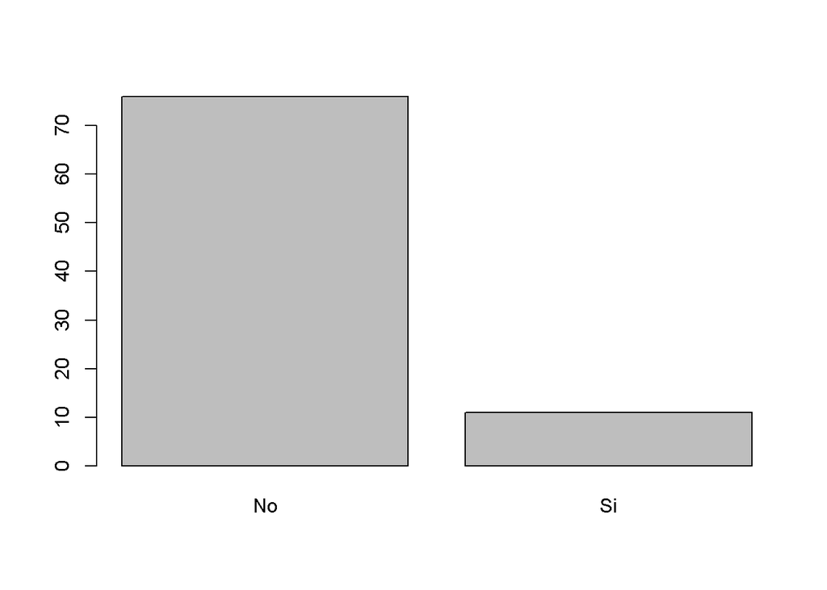

## Análisis de la variable Espionaje por Internet ¿Cree en el Espionaje a traves del Internet?

```
## No Si
## 28 59
```

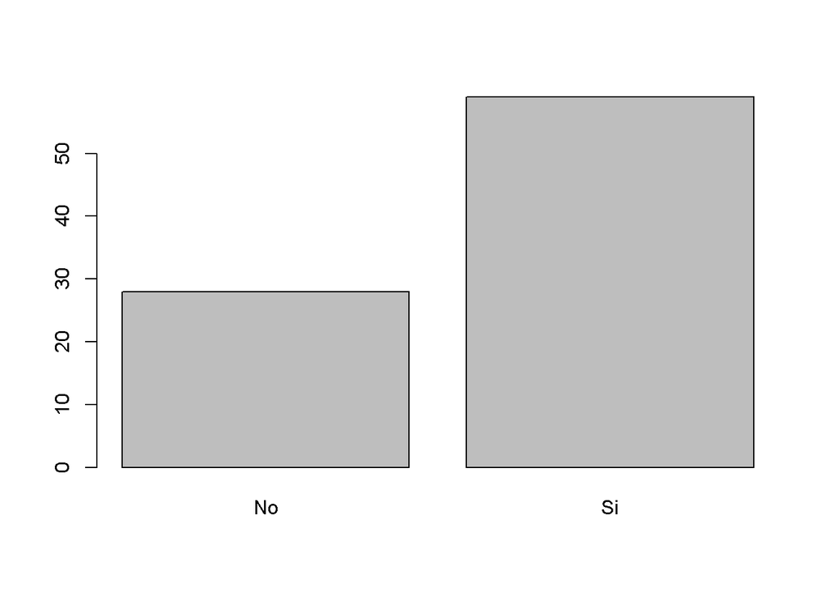

## Análisis de la variable Experimentos ¿Se realizaron experimento en personas afroamericanas en donde no se suministró la penicilina a enfermos con sífilis?

```
## No Si
## 32 55
```

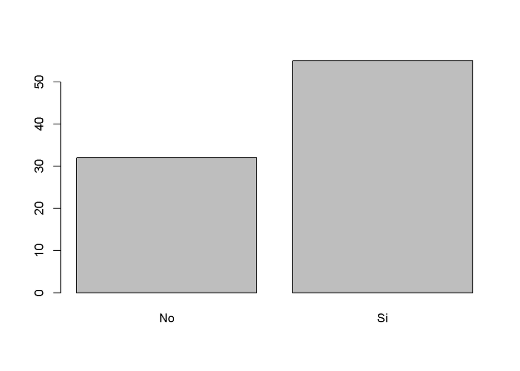

## Análisis de la variable Vacunas ¿Las vacunas no sirven y son una conspiración de las multinacionales farmacéuticas para enriquecers?

```
## No Si
## 84  3
```

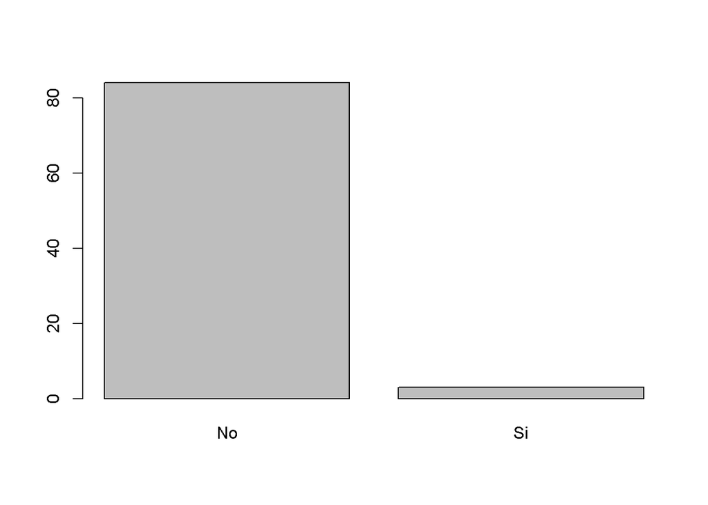

## Análisis de la variable Evidencia Falsa ¿Se utilizó evidencia falsa por el FBI para condenar personas inocentes durante el siglo pasado en EEUU?

```
## No Si
## 19 68
```

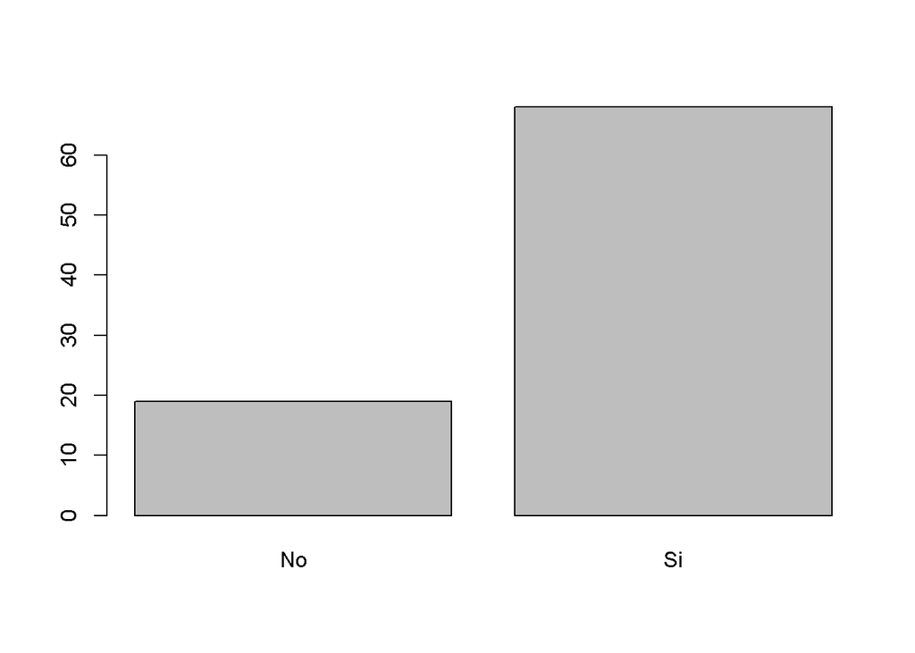

## Análisis de la variable Rafaga Solares ¿Las ráfagas solares causan los sismos en la tierra?

```
## No Si
## 67 20
```

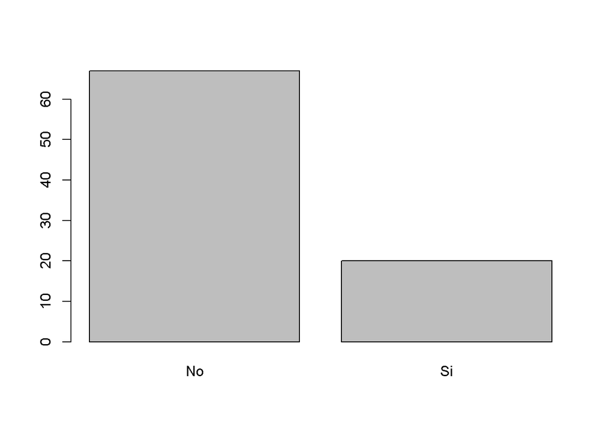

## Análisis de la variable Tierra Hueca ¿La tierra es hueca y en su interior existe una civilización oculta?

```
## No Si
## 82  5
```

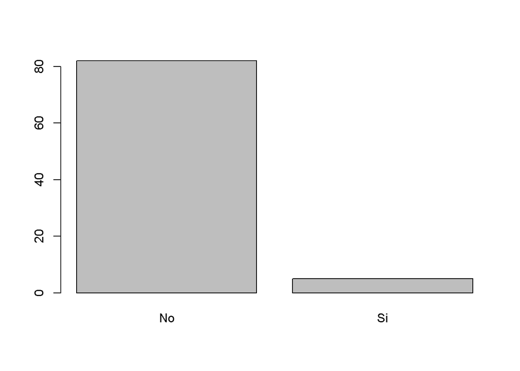

## Análisis de la variable Alienigenas ¿Los alienígenas visitaron las civilizaciones antiguas, influyeron en sus historia y construyeron los mega monumentos de la antigüedad?

```
##
## No Si
## 56 31
```

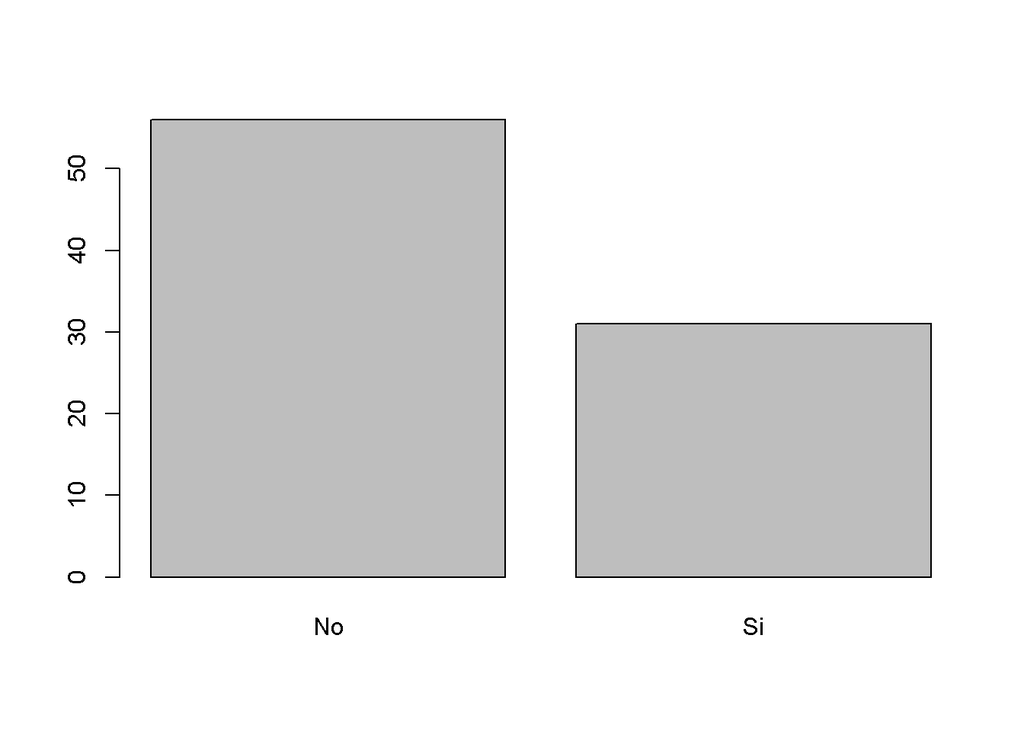

## Análisis de la variable Cambio Climatico ¿Los efectos del cambio climático son naturales, y el escándalo se debe a conspiraciones de ambientalistas y de ciertos gremios económicos?

```
## No Si
## 73 14
```

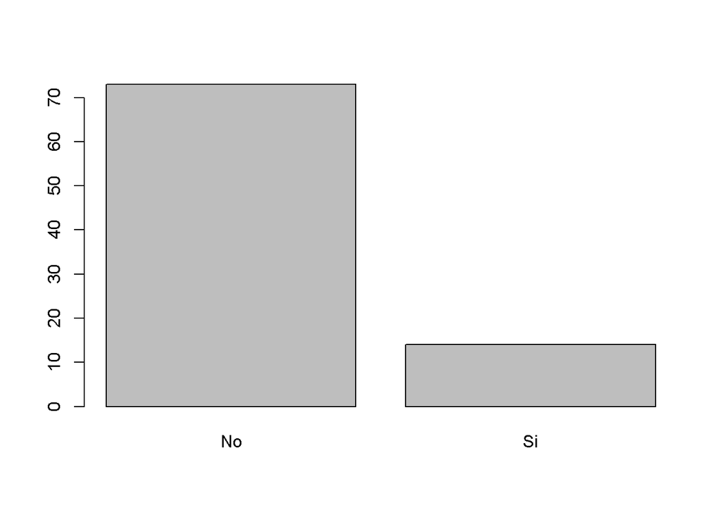

## Análisis de la variable área

```
##
##                    1 : 7.5*pi                      2 : 6*pi
##                             3                             9
##                    3 : 4.5*pi                      4 : 4*pi
##                            13                            39
##                      5 : 3*pi 6 : Ninguna de las anteriores
##                             5                            18
```

### Cambio de la variable área Frecuencia relativa para hacer un análisis posteriormente.

```
##
##                    1 : 7.5*pi                      2 : 6*pi
##                      3.448276                     10.344828
##                    3 : 4.5*pi                      4 : 4*pi
##                     14.942529                     44.827586
##                      5 : 3*pi 6 : Ninguna de las anteriores
##                      5.747126                     20.689655
```

### Se presentará en un grafico de pastel el porcentaje de estudiantes que seleccionaron cada una de las posibles opciones de respuesta a la pregunta sobre área sombreada de una circunferencia

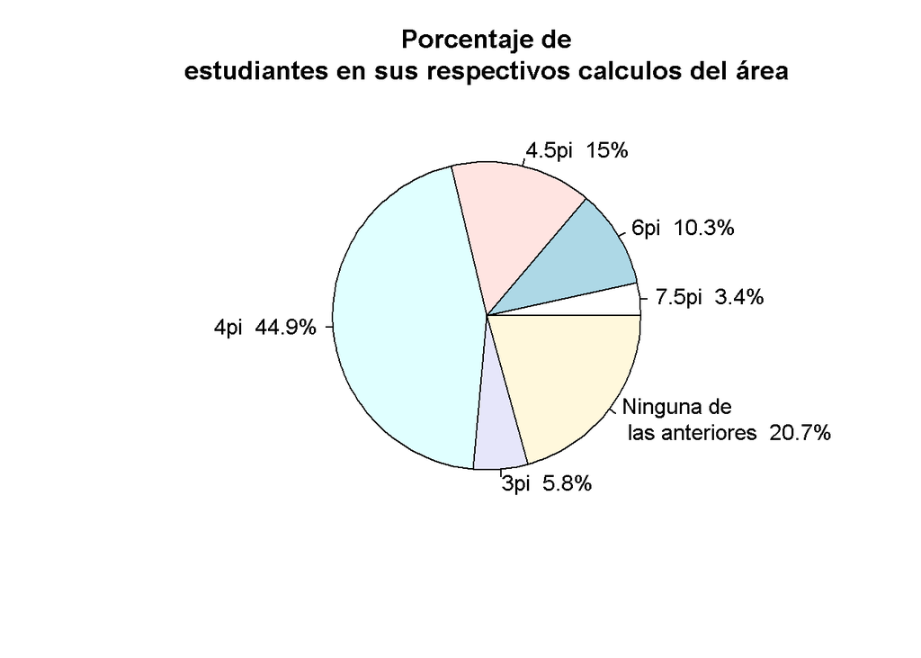

## Análisis de la variable Porcentaje que respondieron bien la respuesta anterior

```
##    Min. 1st Qu.  Median    Mean 3rd Qu.    Max.    NA's
##    0.10   30.75   50.00   52.25   70.00  100.00       1
```

## Análisis de la variable Porcentaje que respondieron bien de los Divisores

```
##    Min. 1st Qu.  Median    Mean 3rd Qu.    Max.    NA's
##    0.50   33.50   60.00   53.46   70.00  100.00       1
```

# ANÁLISIS BIVARIADO

## Cruce variable PAPA con Carreras

#### Se hace una visualización del comportamiento del PAPA con respecto a las carreras registradas en la base de datos, para verificar si tal como pensamos; *¿será los estudiantes de Estadistica por ser semi-primíparos en la universidad tienen un mejor (mayor) PAPA?*

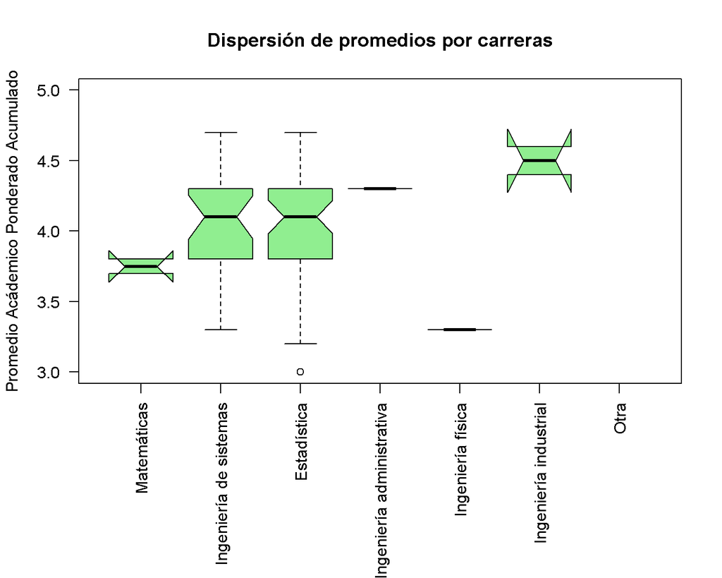

Esta pregunta se puede responder claramente con un *No* a nivel general de todos los estudiantes, y al ser comparado con los estudiantes de ingeniería de sistemas, no se puede concluir que grupo tiene el PAPA más elevado.

## CRUCE PAPA CON EDAD

###### Se representará por medio de un gráfico de dispersión el comportamiento de PAPA deacuerdo a la edad de los estudiantes, para reforzar o refutar la idea de que *¿A mayor edad, mejor será el promedio académico ya que se cuenta con más experiencia, y por ende mejores métodos de aprendizaje adquiridos a lo largo de sus años?* ¡Veamoslo!

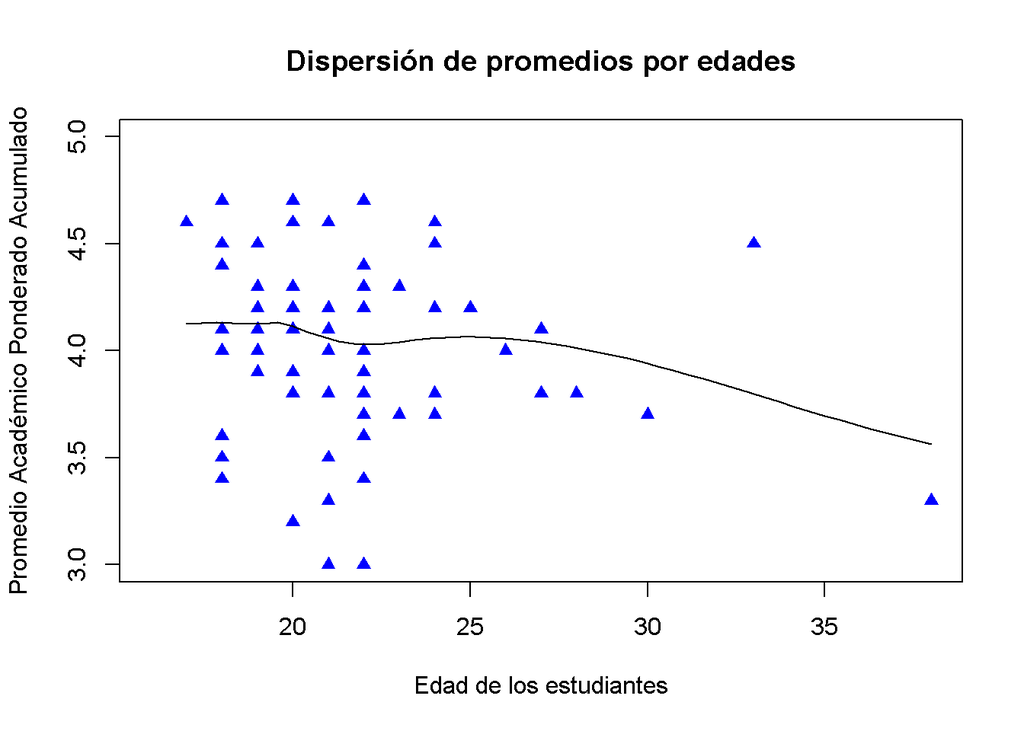

Al observar los datos podemos ver que los promedios mas altos se cocentran en los estudiantes de edades entre *18-22* así que al compararlos con lo que pensabamos; refutamos la idea que teníamos pero no podemos decir que los años y la experiencia no ayudan en la parte académica.

##### Presentaremos un gráfico que relacione la edad de los estudiantes con la carrera que cursan, para respondernos la pregunta *¿Los estudiantes de menor edad son los de estadistica?, al ser una asignatura que se ve en primeros semestres de su malla curricular)?*

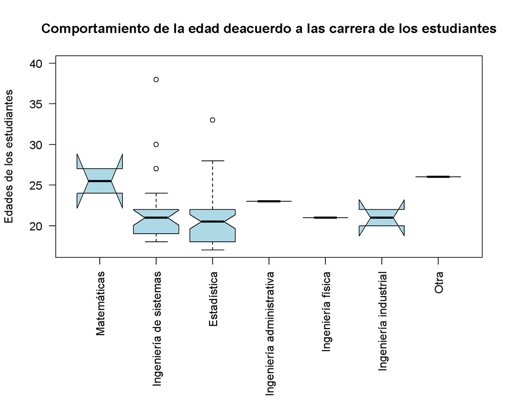

Al traslaparse esta información en particular con el grupo de estudiantes de ingeniería de sistemas; no podemos decir con certeza que *sí* pues aúnque el estudiante más joven es de Estadística; existen intervalos de confianza en el mismo rango de las edades para estos dos grupos, lo que quiere decir que entre éstos dos, estan los estudiantes más jovenes de la encuesta.

# ANÁLISIS MULTIVARIADO

Se espera que en la pregunta relacionada con la gráfica, las carreras relacionadas con matemáticas obtengan un mejor puntaje. A la vez queremos analizar si el nivel del semestre influye en contestar correctamente.

## Analisís multivariado, Semestre, carrera, respuesta correcta a la pregunta del área

### Gráfica de puntos, el color rojo indica que el estudiante acertó la pregunta, el color azul que falló

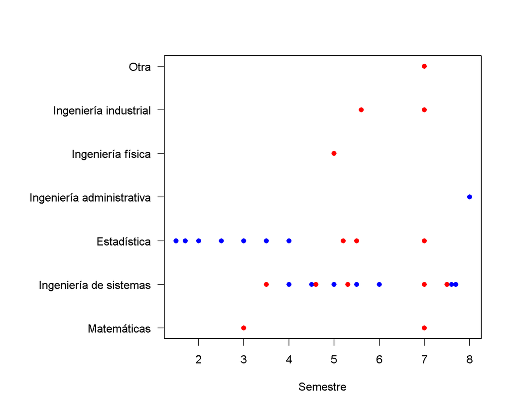

### Análisis numérico de los estudiantes que acertaron la pregunta según la carrera

```
##                          1 : Matemáticas
##                                        2
## 2 : Ingeniería de sistemas e informática
##                                       12
##                          3 : Estadística
##                                       21
##            4 : Ingeniería administrativa
##                                        0
##                    5 : Ingeniería física
##                                        1
##                6 : Ingeniería industrial
##                                        2
##                                 7 : Otra
##                                        1
```

### Análisis numérico de los estudiantes que fallaron la encuesta según la carrera

```
##                          1 : Matemáticas
##                                        0
## 2 : Ingeniería de sistemas e informática
##                                       14
##                          3 : Estadística
##                                       33
##            4 : Ingeniería administrativa
##                                        1
##                    5 : Ingeniería física
##                                        0
##                6 : Ingeniería industrial
##                                        0
##                                 7 : Otra
##                                        0
```

### Análisis numérico de los estudiantes que acertaron la pregunta según el semestre

```
##    Min. 1st Qu.  Median    Mean 3rd Qu.    Max.
##   1.500   2.000   4.000   3.928   5.250   7.500
```

### Análisis numérico de los estudiantes que fallaron la pregunta según el semestre

```
##    Min. 1st Qu.  Median    Mean 3rd Qu.    Max.    NA's
##   1.500   2.000   2.500   3.223   4.000   8.000       1
```

Partiendo del hecho que las carreras con más personas son ingeniería de sistemas y estadística, podemos que mientras ing de sistemas está equilibrado entre estudiantes que acertaron y fallaron, estadística se inclina un poco más a fallar. Esto tal vez se deba a que gran parte de los estudiantes de estadística son de primeros semestres, donde sí hay una clara tendencia de más fallo en la respuesta a la pregunta

## Analisís multivariado, Semestre, carrera, y si tiene instalado el Rstudio

Nos preguntamos si los estudiantes que tenían instalado Rstudio al momento de la encuesta son en su mayoría estudiantes de estadística o en su defecto de semestres avanzados

### Gráfica de puntos, el color rojo indica que el estudiante tenía instalado Rstudio, el color azul que no

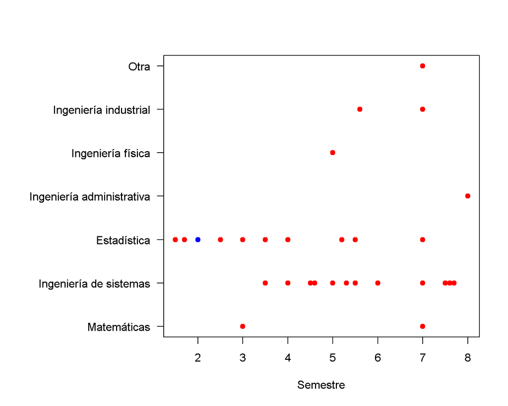

### Análisis numérico de los estudiantes que tenían Rstudio instalado pregunta según la carrera

```
##                          1 : Matemáticas
##                                        2
## 2 : Ingeniería de sistemas e informática
##                                       25
##                          3 : Estadística
##                                       44
##            4 : Ingeniería administrativa
##                                        1
##                    5 : Ingeniería física
##                                        1
##                6 : Ingeniería industrial
##                                        2
##                                 7 : Otra
##                                        1
```

### Análisis numérico de los estudiantes que no tenían Rstudio instalado según la carrera

```
##                          1 : Matemáticas
##                                        0
## 2 : Ingeniería de sistemas e informática
##                                        1
##                          3 : Estadística
##                                       10
##            4 : Ingeniería administrativa
##                                        0
##                    5 : Ingeniería física
##                                        0
##                6 : Ingeniería industrial
##                                        0
##                                 7 : Otra
##                                        0
```

```
##  [1] 2 : Ingeniería de sistemas e informática
##  [2] 3 : Estadística
##  [3] 3 : Estadística
##  [4] 3 : Estadística
##  [5] 3 : Estadística
##  [6] 3 : Estadística
##  [7] 3 : Estadística
##  [8] 3 : Estadística
##  [9] 3 : Estadística
## [10] 3 : Estadística
## [11] 3 : Estadística
## 7 Levels: 1 : Matemáticas ... 7 : Otra
```

### Análisis numérico de los estudiantes que tenían Rstudio instalado según el semestre

```
##    Min. 1st Qu.  Median    Mean 3rd Qu.    Max.
##     1.5     2.0     3.0     3.7     5.0     8.0
```

### Análisis numérico de los estudiantes que no tenían Rstudio instalado según el semestre

```
##  [1] 5.0 2.0 3.5 1.5 2.0 2.0 1.5 2.0  NA 2.0 2.0
```

```
##    Min. 1st Qu.  Median    Mean 3rd Qu.    Max.    NA's
##    1.50    2.00    2.00    2.35    2.00    5.00       1
```

Los estudiantes que no tenían instalado Rstudio marcan tendencia de ser de semestres tempraneros, y vemos que siendo 11, 10 de estos son de estadística, lo que nos indica que los estudiantes de estadística en gran parte están cursando los primeros semestres y apenas están entrando en el mundo de la programación

## Analisís multivariado, edad, semestre, conspiración de alienígenas

….. Nos preguntamos en los estudiantes que creen que los alienígenas ayudaron civilizaciones antiguas la edad cómo influye. Si al ser mayor se cree menos en conspiraciones o por el contrario tiene más mitos impregnados en sí, también es interesante analizar si el nivel de avance en la carrera influye en esta respuesta

### Gráfica de puntos, el color rojo indica que el estudiante cree que los alienígenas ayudaron a civilizaciones antiguas, el color azul que no

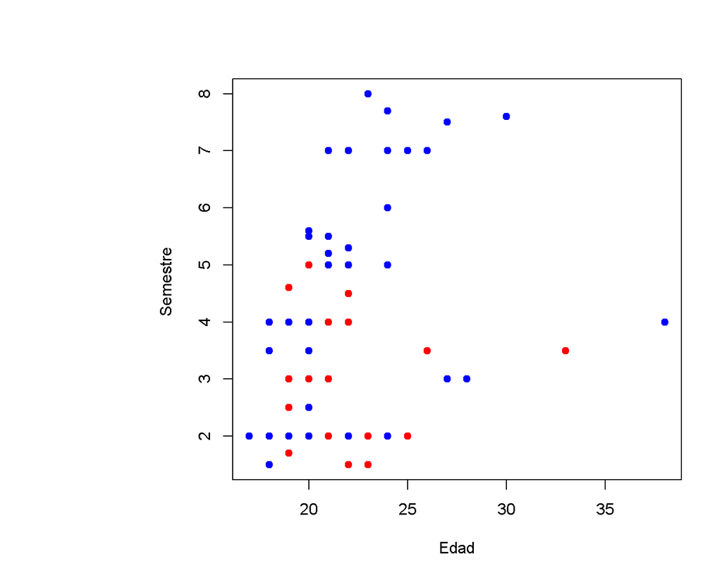

### Análisis numérico de los estudiantes que creen en que los alienigenas ayudaron a civilizaciones según el semestre

```
##    Min. 1st Qu.  Median    Mean 3rd Qu.    Max.    NA's
##   1.500   2.000   2.000   2.643   3.375   5.000       1
```

### Análisis numérico de los estudiantes que no creen en que los alienigenas ayudaron a civilizaciones según el semestre

```
##    Min. 1st Qu.  Median    Mean 3rd Qu.    Max.
##   1.500   2.000   4.000   4.025   5.500   8.000
```

### Análisis numérico de los estudiantes que creen en que los alienigenas ayudaron a civilizaciones según la edad

```
##    Min. 1st Qu.  Median    Mean 3rd Qu.    Max.
##   18.00   19.00   21.00   21.13   22.00   33.00
```

### Análisis numérico de los estudiantes que no creen en que los alienigenas ayudaron a civilizaciones según la edad

```
##    Min. 1st Qu.  Median    Mean 3rd Qu.    Max.
##   17.00   19.00   21.00   21.45   23.00   38.00
```

## Analisís multivariado, edad, semestre , PAPA

Queremos saber si a los mayores les va mejor que a los jovenes dependiendo también del nivel de avance en la carrera

```
##    Min. 1st Qu.  Median    Mean 3rd Qu.    Max.    NA's
##   3.000   3.800   4.100   4.042   4.300   4.700       9
```

### Gráfica de puntos, los colores nos indican en cuál cuartil están, rojo para papa < 3.8, dorado para 3.8 < papa < 4.042, verde para 4.042 < papa < 4.3, azul para papa > 4.3

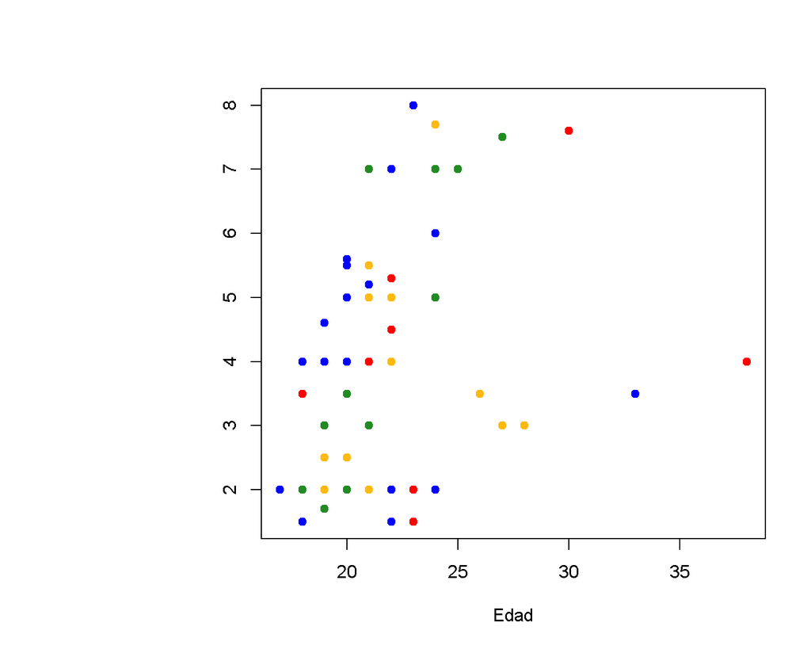

### hacer el análisis numérico tendremos en cuenta la media, para dividir los que están abajo de la media como menos buenos que los que están arriba

### Análisis numérico de los estudiantes con un PAPA “bueno” según el semestre

```
##    Min. 1st Qu.  Median    Mean 3rd Qu.    Max.
##   1.500   2.000   3.500   3.746   5.000   8.000
```

### Análisis numérico de los estudiantes con un PAPA “no bueno” según el semestre

```
##    Min. 1st Qu.  Median    Mean 3rd Qu.    Max.
##   1.500   2.000   3.000   3.489   4.500   7.700
```

### Análisis numérico de los estudiantes con un PAPA “bueno” según la edad

```
##    Min. 1st Qu.  Median    Mean 3rd Qu.    Max.
##   17.00   19.00   20.00   20.98   22.00   33.00
```

### Análisis numérico de los estudiantes con un PAPA “no bueno” según la edad

```
##    Min. 1st Qu.  Median    Mean 3rd Qu.    Max.
##    18.0    19.0    21.0    21.7    22.0    38.0
```

## Analisís multivariado, edad, estrato , PAPA

Ahora nos interesa saber si teniendo en cuenta la edad, el estrato influye en el papa de las personas

### Gráfica de puntos, los colores nos indican en cuál cuartil están, rojo para papa < 3.8, dorado para 3.8 < papa < 4.042, verde para 4.042 < papa < 4.3, azul para papa > 4.3

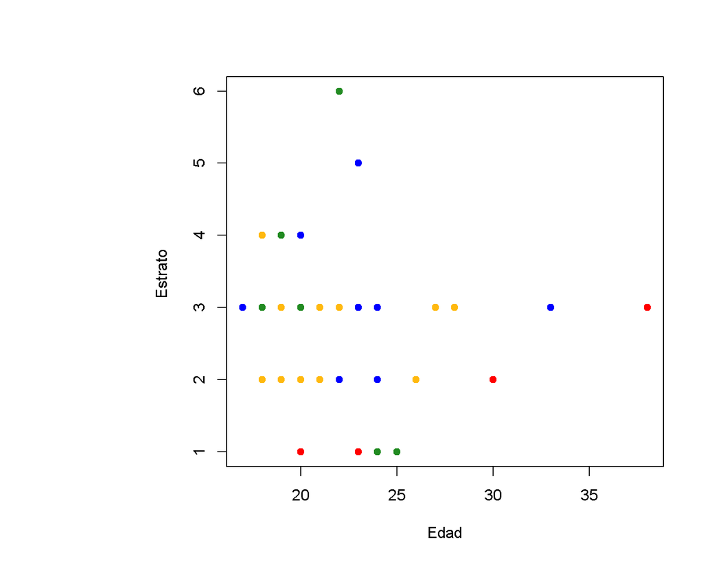

### Análisis numérico de los estudiantes con un PAPA “bueno” según el estrato

```
##            2 : 1            3 : 2            4 : 3            5 : 4
##                2               13               20                4
##            6 : 5 8 : No se conoce
##                1                1
```

### Análisis numérico de los estudiantes con un PAPA “no bueno” según el estrato

```
##            2 : 1            3 : 2            4 : 3            5 : 4
##                3               11               21                2
##            6 : 5 8 : No se conoce
##                0                0
```

### Análisis numérico de los estudiantes con un PAPA “bueno” según la edad

```
##    Min. 1st Qu.  Median    Mean 3rd Qu.    Max.
##   17.00   19.00   20.00   20.98   22.00   33.00
```

#### Análisis numérico de los estudiantes con un PAPA “no bueno” según la edad

```
##    Min. 1st Qu.  Median    Mean 3rd Qu.    Max.
##    18.0    19.0    21.0    21.7    22.0    38.0
```

```
##    Min. 1st Qu.  Median    Mean 3rd Qu.    Max.
##    0.00   71.00   88.00   78.42   95.00  100.00
```

## Analisís multivariado, edad, percentilPruebasSaber , PAPA, Espionaje

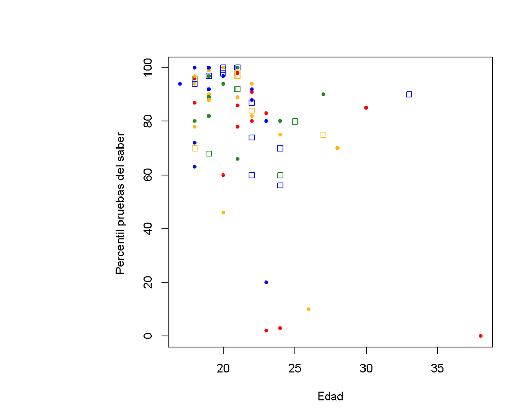

En la población notamos que las personas con edades inferiores a 25 años cuyos percentiles obtenidos son mayores o iguales a 80 tienden a creer en el espionaje por ser la población que más navega en internet, (dentados con puntos)

### Análisis numérico

```
##    Min. 1st Qu.  Median    Mean 3rd Qu.    Max.
##   20.00   74.00   90.00   84.32   97.00  100.00
```

```
##    Min. 1st Qu.  Median    Mean 3rd Qu.    Max.
##    0.00   75.00   87.00   77.08   94.00  100.00
```

```
##    Min. 1st Qu.  Median    Mean 3rd Qu.    Max.
##    0.00   78.00   89.00   80.05   94.00  100.00
```

```
##    Min. 1st Qu.  Median    Mean 3rd Qu.    Max.
##    0.00   60.00   77.50   75.00   96.25  100.00
```

Podemos ver que el PAPA de las personas que estuvieron en un buen percentil en las pruebas del saber es un poco mejor, y en cuanto al espionaje los que no creen estuvieron un poquito peor.

```
##    Min. 1st Qu.  Median    Mean 3rd Qu.    Max.
##   17.00   19.00   20.00   20.98   22.00   33.00
```

```
##    Min. 1st Qu.  Median    Mean 3rd Qu.    Max.
##   18.00   20.00   21.50   21.86   22.50   33.00
```

En cuanto a la edad se puede ver que hay más tendencia a los jovenes para creer que hubo espionaje

## Analisís multivariado, edad, percentilPruebasSaber, Aterrizaje en la luna

Analizaremos qué tanto tiene que ver la edad y el porcentaje de las pruebas del saber en la creencia que el hombre llegó a la luna, rojo indica que cree que es un montaje, azul cree lo contrario

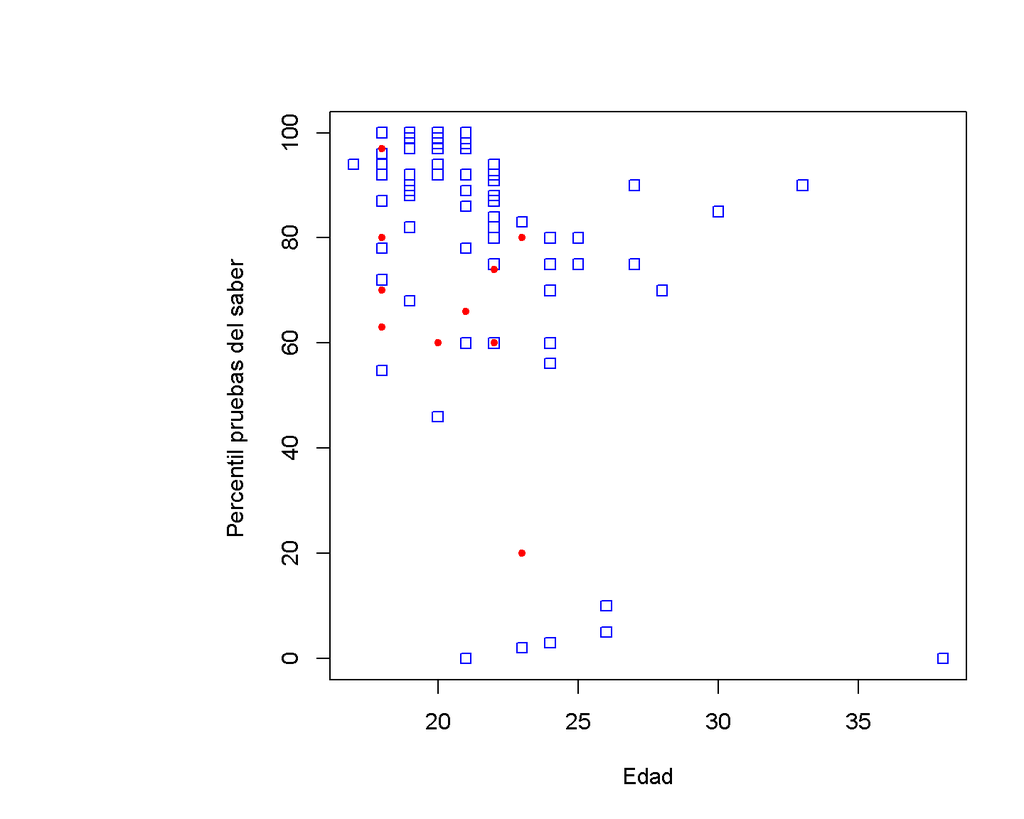

### Analisis numérico

```
##    Min. 1st Qu.  Median    Mean 3rd Qu.    Max.
##   18.00   18.00   21.00   20.45   22.00   23.00
```

```
##    Min. 1st Qu.  Median    Mean 3rd Qu.    Max.
##   17.00   19.00   21.00   21.46   22.00   38.00
```

```
##    Min. 1st Qu.  Median    Mean 3rd Qu.    Max.
##   20.00   60.00   66.00   66.36   77.00   97.00
```

```
##    Min. 1st Qu.  Median    Mean 3rd Qu.    Max.
##    0.00   75.00   89.50   80.17   96.25  100.00
```

Podemos ver que el promedio del saber de las personas que no creen en la coonspiración es considerablemente mayor, mientras que los que creen en la conspiración son un poco más escépticos

## RECOMENDACIONES

1. Para la tabla de datos debería omitirse de ella la primera variable que asigna un número aleoatorio a cada fila puesto que no representa importancia significativa dentro de ésta.

## CONCLUSIONES

Podemos ver que la universidad como es de carácter público la mayoría de sus estudiantes son de estrato 1, 2, y 3 medianamente, por lo cual es escaso encontrar estudiantes con estratos elevados .